# ESM 244 Homework 02

Laura Gray

February 7, 2019

## 1. Wrangling and Visualizing Data for Tidy Tuesday: Cetaceans in captivity in the US (1938-2017)

- Source: *The Pudding* article, Free Willy and Flipper by the Numbers, 2017 (& Tidy Tuesday)
- What is this?: A collection of all data that I could find on whales and dolphins that spent some period of time captive in the US between 1938 and May 7, 2017.
- Source(s): The data used to create this aggregated set came from the US National Marine Mammal Inventory (original data requested on June 15, 2015 via FOIA available here) and from Ceta-Base. Data from Ceta-Base were downloaded May 7, 2017.
- Last Modified: May 7, 2017
- Contact Information: Amber Thomas
- Spatial Applicability: United States
- Temporal Applicability: March 1, 1938 - May 7, 2017

### A. Explore variables and observations

```r
captive_cetacean <- read_csv("~/github/ESM244-HW02/captive_cetacean.csv")
#View(captive_cetacean)

unique(captive_cetacean$species) #42 species, some seem wrong...
```

```
##  [1] "Bottlenose"               "Killer Whale; Orca"
##  [3] "Beluga"                   "Hybrid"
##  [5] "Commerson's"              NA
##  [7] "alternatively spelled"    "White-sided, Pacific"
##  [9] "Backcross"                "Rough-toothed"
## [11] "Pilot, Short-fin"         "Spotted, Atlantic"
## [13] "Spotted, Pantropical"     "Pseudorca"
## [15] "River, Amazon"            "Tucuxi"
## [17] "Pilot, Short-finned"      "Common"
## [19] "Risso's"                  "Common, Long-beak"
## [21] "Rough-Toothed"            "Pantropical Spotted"
## [23] "Atlantic Spotted"         "F"
## [25] "Long-Finned Pilot Whale"  "Short-Finned Pilot Whale"
## [27] "Pacific White-Sided"      "Common; Saddleback"
## [29] "Beluga Whale"             "Spinner"
## [31] "Harbor Porpoise"          "White-Beaked"
## [33] "Atlantic White- Sided"    "False Killer Whale"
## [35] "Amazon River; Boto"       "Unspecified Or Porpoise"
## [37] "Melon-Headed Whale"       "U"
## [39] "Pygmy Killer Whale"       "Unspecified Pilot Whales"
## [41] "CHRONIC"                  "Northern Right Whale"
```

```r
length(unique(captive_cetacean$name)) #1373 individuals
```

```
## [1] 1373
```

```r
unique(captive_cetacean$status) #all of interest (e.g. alive, escaped, unknown, stillbirth...)
```

```
##  [1] "Alive"                NA                     "Died"
##  [4] "Miscarriage"          "Stillbirth"           "Escaped (Found Dead)"
##  [7] "Released?"            "Escaped"              "Unknown"
## [10] "Released"
```

```r
unique(captive_cetacean$acquisition) #of interest: born, rescue, capture
```

```
## [1] "Born"         NA             "Rescue"       "Capture"
## [5] "Miscarriage"  "Stillbirth"   "Unknown"      "1979-10-28\\"
```

### B. Explore acquisition (born/resue/capture) vs. status (alive/dead/etc.)

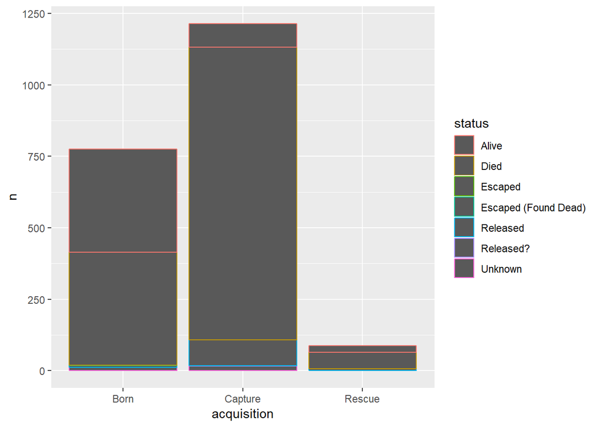

```r
cc_status <- captive_cetacean %>%
  filter(acquisition == "Born" | acquisition == "Rescue" | acquisition == "Capture") %>%
  group_by(acquisition, status) %>%
  tally()
ggplot(cc_status, aes(x=acquisition, y=n)) +
  geom_bar(stat = "identity", aes(color=status))
```

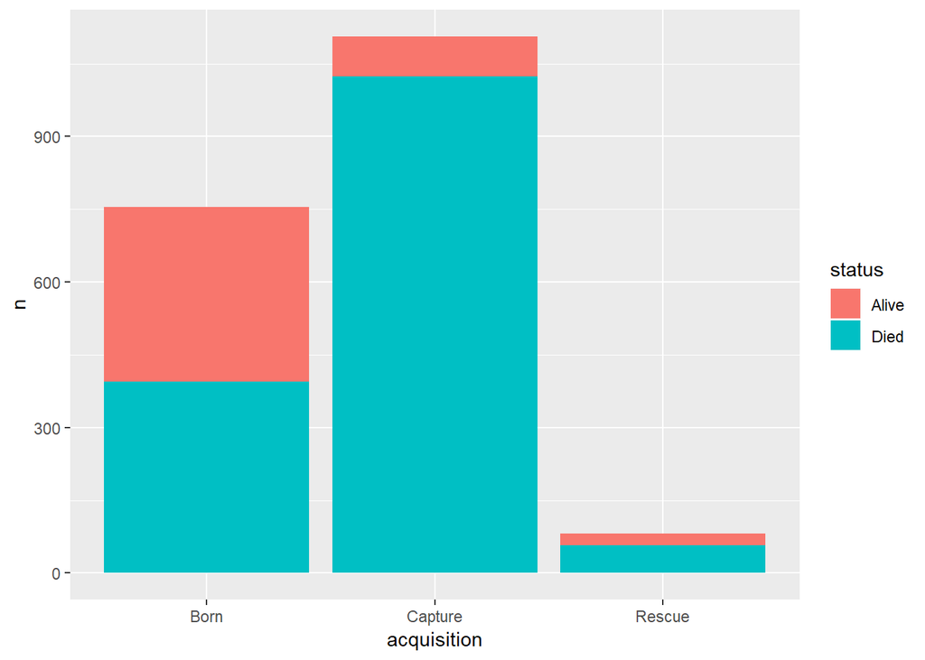

```r
cc_alivedead <- cc_status %>%
  filter(status == "Alive" | status == "Died")
ggplot(cc_alivedead, aes(x=acquisition, y=n, fill = status)) +
  geom_bar(stat = "identity")
```

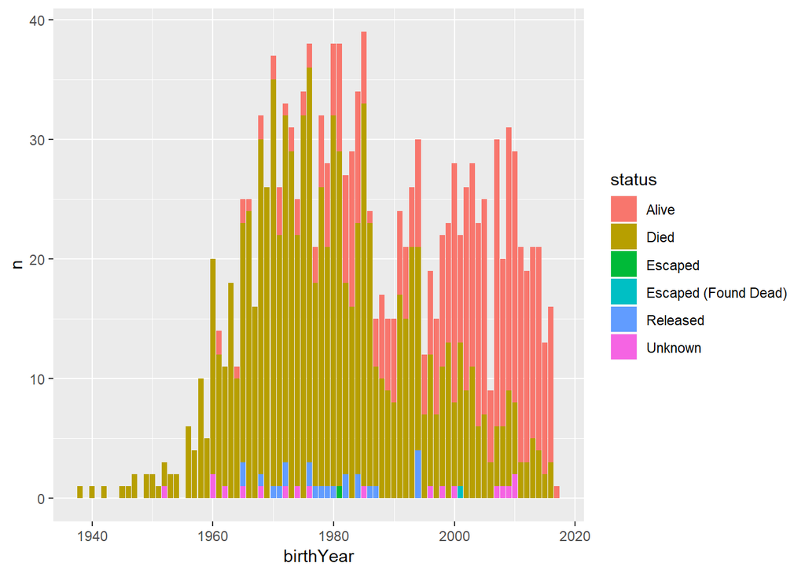

```r
#Looking at this graph, one would think that greater proportions of captured whales tend to die than those born in captivity. But this might be masked by the effects of time, as well. Does not illustrate whale age...


cc_yearstatus <- captive_cetacean %>%
  filter(acquisition == "Born" | acquisition == "Rescue" | acquisition == "Capture") %>%
  filter(birthYear != "NA") %>%
  group_by(birthYear, acquisition, status) %>%
  tally()
cc_yearstatus$birthYear <- as.numeric(cc_yearstatus$birthYear)
ggplot(cc_yearstatus, aes(x=birthYear, y=n, fill = status)) +
  geom_bar(stat = "identity")
```

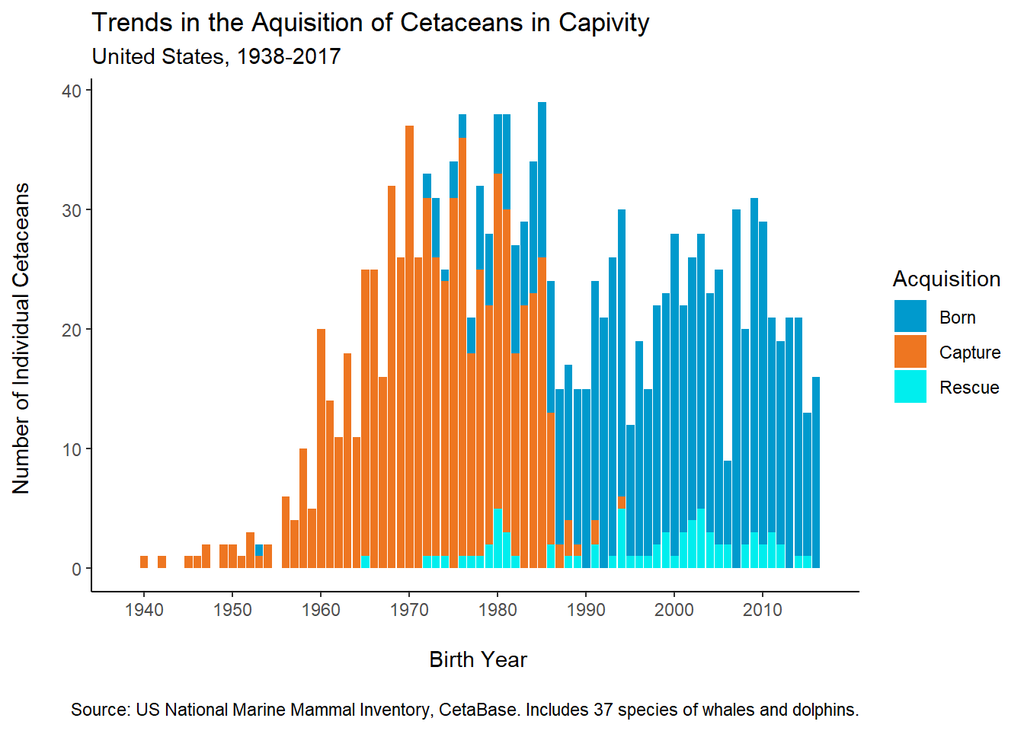

```r
ggplot(cc_yearstatus, aes(x=birthYear, y=n, fill = acquisition)) +
  geom_bar(stat = "identity") +
  scale_fill_manual(values=c("deepskyblue3", "chocolate2", "cyan2"), name = "Acquisition") +
  ylab("Number of Individual Cetaceans \n") +
  xlab("\n Birth Year") +
  #ggtitle("Trends in the Acquisition of Cetaceans in Capivity (USA, 1938-2017) \n") +
  scale_x_continuous(limits = c(1938,2017), breaks=seq(1940,2010,10)) +
  labs(title="Trends in the Aquisition of Cetaceans in Capivity", subtitle="United States, 1938-2017", caption="\n Source: US National Marine Mammal Inventory, CetaBase. Includes 37 species of whales and dolphins.") +
  theme_classic()
```

## 2. Parameter Estimation - Wild Fish Catch

Source: Global wild fish catch and aquaculture production, compiled by Earth Policy Institute with 1950-2010 from U.N. Food and Agriculture Organization (FAO), Global Capture Production and Global Aquaculture Production, electronic databases, at www.fao.org/fishery/topic/16140/en.

1950-2012 unit = million tons

**Notes: Fish data include fishes, crustaceans, mollusks, and various other aquatic animals. Crocodiles, alligators, and aquatic mammals are excluded. Figures for 2011 are estimates; figures for 2012 are projections.**

### A. Visualize Data

```r
fish_catch <- read_csv("~/github/ESM244-HW02/fish_catch.csv")
```

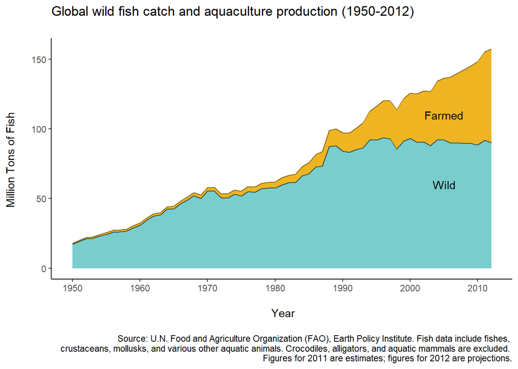

```r
fish <- fish_catch %>%
  rename(Year = `World Wild Fish Catch and Farmed Fish Production, 1950-2012`, Wild = X2, Farmed = X3, Total = X4) %>%
  filter(Year != "NA", Year != "Year", Wild != "NA", Farmed != "NA", Total != "NA")

fish$Year <- as.numeric(fish$Year)
fish$Total <- as.numeric(fish$Total)
fish$Wild <- as.numeric(fish$Wild)
fish$Farmed <- as.numeric(fish$Farmed)

ggplot(fish, aes(x=Year, y=Total)) +
  geom_area(fill = "goldenrod2") +
  geom_area(aes(x=Year, y=Wild), fill = "darkslategray3") +
  geom_line(color = "goldenrod4") +
  geom_line(aes(x=Year, y=Wild), color = "darkslategrey") +
  ylab("Million Tons of Fish \n") +
  xlab("\n Year") +
  labs(title="Global wild fish catch and aquaculture production (1950-2012) \n",
       caption="\n Source: U.N. Food and Agriculture Organization (FAO), Earth Policy Institute. Fish data include fishes, \n crustaceans, mollusks, and various other aquatic animals. Crocodiles, alligators, and aquatic mammals are excluded. \n Figures for 2011 are estimates; figures for 2012 are projections.") +
  theme(plot.caption = element_text(hjust = 0.5)) +
  annotate("text", x = c(2005,2005), y = c(60,110), label = c("Wild", "Farmed")) +
  scale_x_continuous(breaks=seq(1940,2010,10)) +
  theme_classic()
```

### B. Nonlinear Least Squares

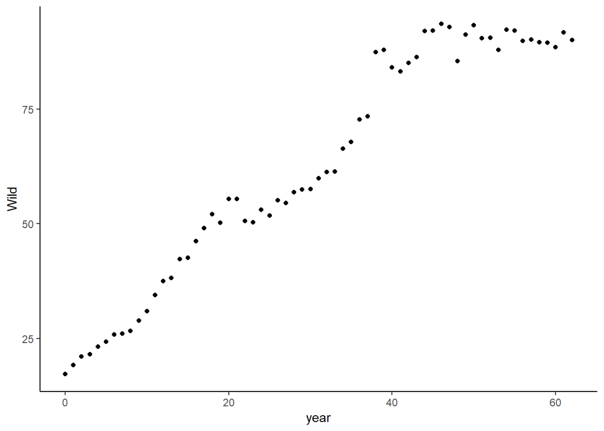

```r
#merged this first chunk into code below
#wild_pd1 <- fish %>%
  #filter(Year < 1988)
#ggplot(wild_pd1, aes(x=Year, y=Wild)) +
  #geom_point() +
  #theme_classic()

wildfish <- fish %>%
  mutate(year = Year -1950) %>%
  #filter(Year < 1988) %>%
  select(year, Wild)
ggplot(wildfish, aes(x=year, y=Wild)) +
  geom_point() +
  theme_classic()
```

- The trend in wild catch is increasing until 1988, and then levels off until 2012. **Logistic growth** doesn’t look like a great fit, here, but we’re going to go with it!
- **Parameter estimation**: K=90, B=8, r=0.025 (see below)

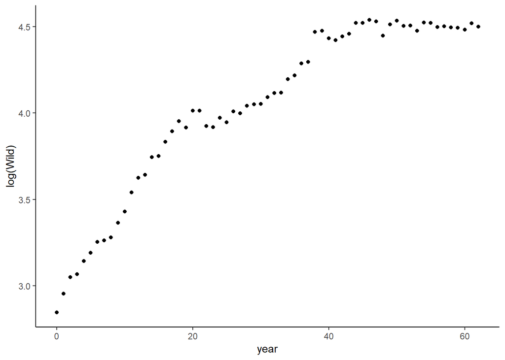

```r
# N = A/(1 + Be^(-rt))
# B = (K-No)/No
# estimate for carrying capacity: 90
# if No is 10, B is 8

# to estimate r...
# since [y=e^(rt)], then [ln(y)=rt] a linear relationship exists!

#log transformed.
ggplot(wildfish, aes(x=year, y=log(Wild))) +
  geom_point() +
  theme_classic()
```

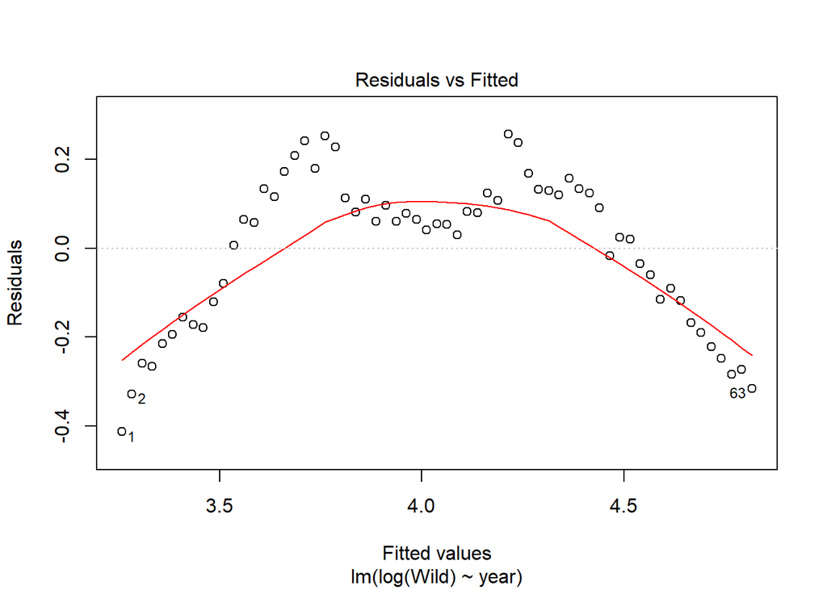

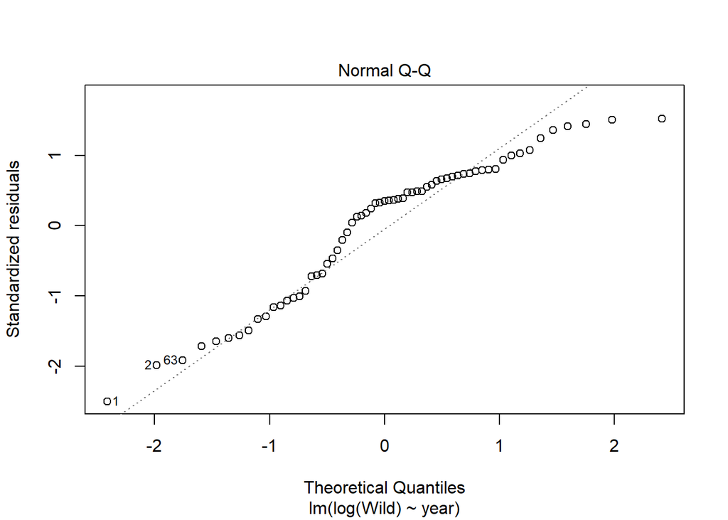

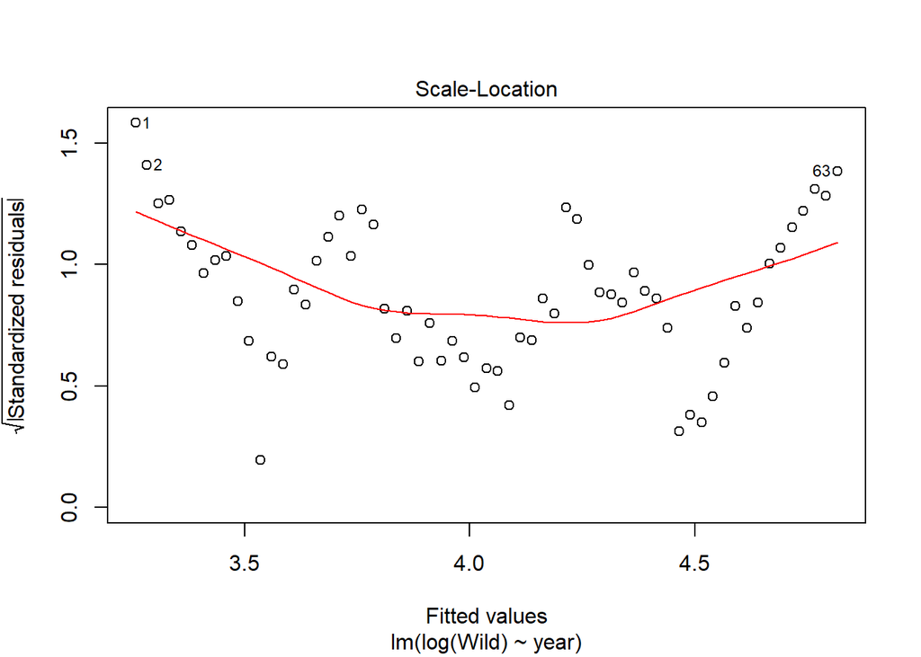

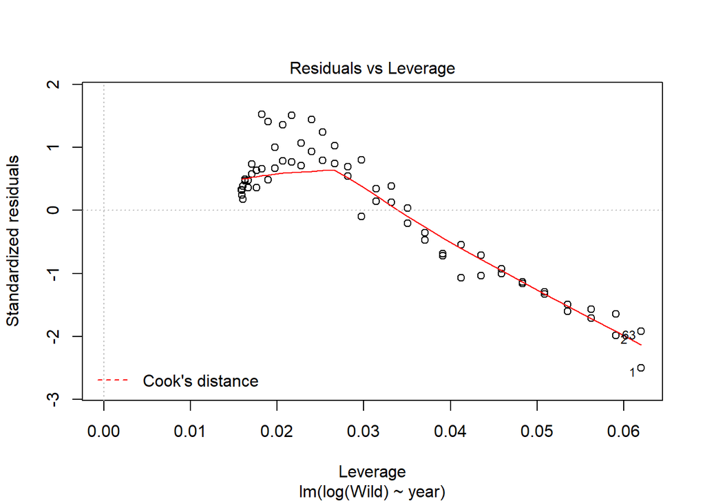

```r
wild_model <- lm(log(Wild) ~ year, data = wildfish)
plot(wild_model) #mehhh not great but oh well
```

```r
wild_model
```

```
##
## Call:
## lm(formula = log(Wild) ~ year, data = wildfish)
##
## Coefficients:
## (Intercept)         year
##     3.25799      0.02514
```

```r
# result: r ~ 0.025

wild_fit <- nls(Wild ~ A/(1 + B*exp(-r*year)),
                start = list(A = 90, B = 8, r = 0.025),
                data = wildfish,
                trace = TRUE)
```

```
## 136882.2 :  90.000  8.000  0.025
## 134881.4 :  67.81432501  5.66495237  0.02727994
## 130752.5 :  50.97655415  3.85037838  0.03164775
## 119079.2 :  43.74827655  2.95893888  0.03950417
## 92341.86 :  46.34757836  2.90666673  0.05109762
## 51240.58 :  58.48300629  3.42646407  0.06272291
## 13433.91 :  79.15449245  4.08414566  0.06916899
## 1366.526 :  100.29050758   4.36366477   0.07000391
## 1365.143 :  100.27594807   4.31674052   0.06989497
## 1365.143 :  100.27906676   4.31629458   0.06988559
## 1365.143 :  100.27830018   4.31633470   0.06988698
```

```r
wild_fit
```

```
## Nonlinear regression model
##   model: Wild ~ A/(1 + B * exp(-r * year))
##    data: wildfish
##         A         B         r
## 100.27830   4.31633   0.06989
##  residual sum-of-squares: 1365
##
## Number of iterations to convergence: 10
## Achieved convergence tolerance: 6.307e-06
```

```r
# store the model coefficients (call the coefficients from the model itself, don't type values)
A <- coef(wild_fit)[1]
B <- coef(wild_fit)[2]
r <- coef(wild_fit)[3]
r
```

```
##          r
## 0.06988698
```

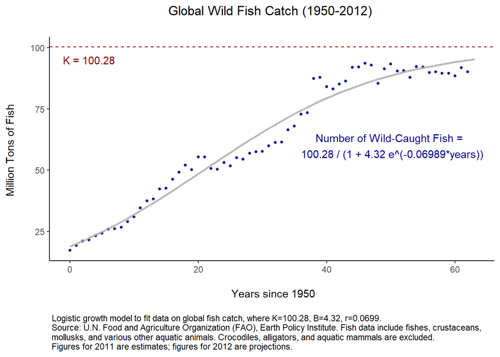

```r
# create a new sequence of time values (time_seq)
time_seq <- seq(0,63, length = 100) #100 total observations over 63 years

# plug this new sequence into my model with the parameters A, B, and r that we found
wild_predict <- A/(1+B*exp(-r*time_seq))

# bind that together with my time sequence data
wildpred_df <- data.frame(time_seq, wild_predict)

ggplot(wildfish, aes(x=year, y=Wild)) +
  geom_point(color = "darkblue", size = 1, alpha = 0.9) +
  geom_line(data = wildpred_df, aes(x=time_seq, y=wild_predict), color = "darkgrey", alpha = 0.8, size = 1) +
  ylab("Million Tons of Fish \n") +
  xlab("\n Years since 1950") +
  labs(title="Global Wild Fish Catch (1950-2012) \n",
       caption="\n Logistic growth model to fit data on global fish catch, where K=100.28, B=4.32, r=0.0699. \n Source: U.N. Food and Agriculture Organization (FAO), Earth Policy Institute. Fish data include fishes, crustaceans, \n mollusks, and various other aquatic animals. Crocodiles, alligators, and aquatic mammals are excluded. \n Figures for 2011 are estimates; figures for 2012 are projections.") +
  geom_hline(yintercept=100.3, linetype="dashed", color = "darkred") +
  annotate("text", x = c(3), y = c(95), label = c("K = 100.28"), color = "darkred") +
   annotate("text", x = c(50), y = c(60), label = c("Number of Wild-Caught Fish = \n 100.28 / (1 + 4.32 e^(-0.06989*years))"), color = "darkblue") +
  theme_classic() +
  theme(plot.title = element_text(hjust = 0.5)) +
  theme(plot.caption = element_text(hjust = 0))
```

## 3. Bootstrapped Confidence Interval for Proportions

- 22 out of 36 surveyed UCSB community members (61%) identifying as nonbinary/genderqueer responded that they had personally experienced “exclusionary, offensive, hostile or intimidating conduct” (compared to 26% and 19% for those identifying as women and men, respectively).
- n=36
- prop(hostile) = 0.61
- find 95% confidence interval for that proportion

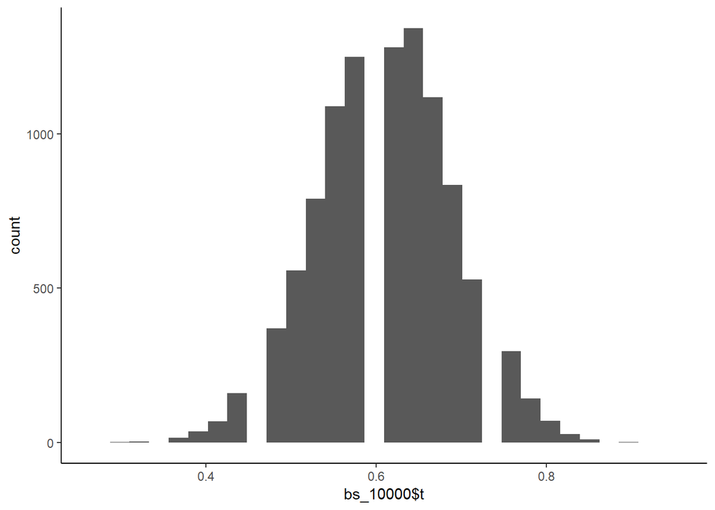

```r
#recreate data in a vector, where 22=hostile(1), 14=none(0)
nonbinary_response <- c(1,1,1,1,1,1,1,1,1,1,1,1,1,1,1,1,1,1,1,1,1,1,
                        0,0,0,0,0,0,0,0,0,0,0,0,0,0)

#create a function to calculate the proportion(hostile) in each bootstrap sample
proportion_fun <- function(x,i) {mean(x[i])}

#bootstrap
bs_10000 <- boot(nonbinary_response, proportion_fun, R = 10000)

#plot to see what's happened
ggplot() +
  aes(bs_10000$t) + #all the mean values
  geom_histogram() +
  theme_classic()
```

```r
#Calculate confidence interval using boot::boot.ci()
boot.ci(bs_10000, conf = 0.95)
```

```
## BOOTSTRAP CONFIDENCE INTERVAL CALCULATIONS
## Based on 10000 bootstrap replicates
##
## CALL :
## boot.ci(boot.out = bs_10000, conf = 0.95)
##
## Intervals :
## Level      Normal              Basic
## 95%   ( 0.4529,  0.7718 )   ( 0.4444,  0.7778 )
##
## Level     Percentile            BCa
## 95%   ( 0.4444,  0.7778 )   ( 0.4167,  0.7222 )
## Calculations and Intervals on Original Scale
```

## 4. RStudio Conference Talks (3)

1. Talk title and speaker name
2. Two bulletpoints (for each talk), interesting things that you learned
3. One question that you would have liked to asked the speaker

*Data science as a team sport - Angela Bassa* https://resources.rstudio.com/rstudio-conf-2019/data-science-as-a-team-sport

- Conflicts of character versus conflicts of understanding or purpose in the workplace
- Gathering folks with apecailization of interests, establishing shareable processes, and establishing trust (especially through diversity and inclusion!) are important aspects of working in teams of data scientists -‘junior’ scientists are less biased in their approaches / make less assumptions, and can therefore contribute something that more experienced scientists might not be able to see (i.e. *the luxury of ignorance*)
- excellence isn’t binary! can vary, day by day, project by project, - give eachother pschological saftey
- Question: teams don’t scale? last few minutes (5-10 sci + 3 engineers is ideal)